# Prueba técnica Machine Learning KAVAK

## Por: Pedraza Nicolás Luis Amaury

La empresa KAVAK nos ha proporcionado un listado de datos el cual utilizaremos para entrenar un modelo que nos ayude a predecir los precios con base en las variables del propio lista

### Paqueterías

Python contiene definidas solo algunas funciones, lo cuál permite realizar operaciones básicas. Pero los módulos o librerías, que son creados y mantenidos por la comunidad, extienden esas funcionalidades. Para instalar un módulo se requiere seguir la siguiente instrucción:

```python
import pandas as pd
import numpy as np
import jedi
import matplotlib.pyplot as plt
import seaborn as sns
from sklearn.model_selection import train_test_split
from sklearn.linear_model import LinearRegression
from sklearn.linear_model import Ridge
from sklearn.tree import DecisionTreeRegressor
```

### Importamos la base de datos

Una vez que hemos cargado las librerías adecuadas para el trabajo, cargamos la base de datos que fue proporcionada vía correo

```python
df = pd.read_csv('C:/Users/lapnt/OneDrive/Documentos/Contratacion KAVAK/Work Sample/train.csv')
```

Una vez cargada el objeto df (data frame) que contiene la base de entrenamiento proporcionada por Kavak, ahora inpeccionamos el objeto para asegurarnos que sea de tipo data frame.

```python
type(df)
```

```
pandas.core.frame.DataFrame
```

Este objeto tiene distintos methods asosiados útiles para el análisis de datos. A diferencia de las funciones, los methods se invocan despues del objeto.

El method shape devuelve un vector que muestra las dimenciones de la data frame, el primer elemento contiene el número de filas de la tabla, y el segundo su número de columnas. En este caso, la base de datos posee un total de 74,111 filas (observaciones) y 29 columnas (variables)

```python
df.shape
```

```
(74111, 29)
```

Ahora lo siguiente, llamaremos las primeras observaciones de la base de datos para analizar qué variables nos serán de utilidad para diagnosticar el precio.

```python
df.head()
```

|  | id | log_price | property_type | room_type | amenities | accommodates | bathrooms | bed_type | cancellation_policy | cleaning_fee | ... | latitude | longitude | name | neighbourhood | number_of_reviews | review_scores_rating | thumbnail_url | zipcode | bedrooms | beds |
| --- | --- | --- | --- | --- | --- | --- | --- | --- | --- | --- | --- | --- | --- | --- | --- | --- | --- | --- | --- | --- | --- |
| 0 | 6901257 | 5.010635 | Apartment | Entire home/apt | {"Wireless Internet","Air conditioning",Kitche... | 3 | 1.0 | Real Bed | strict | True | ... | 40.696524 | -73.991617 | Beautiful brownstone 1-bedroom | Brooklyn Heights | 2 | 100.0 | https://a0.muscache.com/im/pictures/6d7cbbf7-c... | 11201 | 1.0 | 1.0 |
| 1 | 6304928 | 5.129899 | Apartment | Entire home/apt | {"Wireless Internet","Air conditioning",Kitche... | 7 | 1.0 | Real Bed | strict | True | ... | 40.766115 | -73.989040 | Superb 3BR Apt Located Near Times Square | Hell's Kitchen | 6 | 93.0 | https://a0.muscache.com/im/pictures/348a55fe-4... | 10019 | 3.0 | 3.0 |
| 2 | 7919400 | 4.976734 | Apartment | Entire home/apt | {TV,"Cable TV","Wireless Internet","Air condit... | 5 | 1.0 | Real Bed | moderate | True | ... | 40.808110 | -73.943756 | The Garden Oasis | Harlem | 10 | 92.0 | https://a0.muscache.com/im/pictures/6fae5362-9... | 10027 | 1.0 | 3.0 |
| 3 | 13418779 | 6.620073 | House | Entire home/apt | {TV,"Cable TV",Internet,"Wireless Internet",Ki... | 4 | 1.0 | Real Bed | flexible | True | ... | 37.772004 | -122.431619 | Beautiful Flat in the Heart of SF! | Lower Haight | 0 | NaN | https://a0.muscache.com/im/pictures/72208dad-9... | 94117.0 | 2.0 | 2.0 |
| 4 | 3808709 | 4.744932 | Apartment | Entire home/apt | {TV,Internet,"Wireless Internet","Air conditio... | 2 | 1.0 | Real Bed | moderate | True | ... | 38.925627 | -77.034596 | Great studio in midtown DC | Columbia Heights | 4 | 40.0 | NaN | 20009 | 0.0 | 1.0 |

5 rows × 29 columns

### EDA (Exploratory Data Analisys)

El término de EDA viene de las siglas en inglés Exploratory Data Analysis, el cual se enfoca en explorar la base de datos para tomar las decisiones de las variables que nos ayudarán a construir el modelo.

Hasta ahora hemos podido importar la base y realizar algunas operaciones básicas para seleccionar los datos. Ahora seleccionaremos las variables para construir nuestro modelo.

En este ejercicio, nuestro objetivo es predecir el precio alcanzado por un alojamiento, en función de sus características. Primero exploraremos el precio, que es nuestra variable objetivo.

Dado que nuestro objetivo es predecir los precios, eliminaremos las observaciones que no muestren precios o cuyo valor sea NA. En este caso, la variable propiamente ya se encuentra como logaritmo lo cual elimina los sesgos que puedan existir.

```python
df = df[df.log_price != 0]
```

```python
df = df.dropna()
```

```python
df.shape
```

```
(38501, 29)
```

Al darle tratamiento a la base, al final nos quedamos solamente con 38,501 observaciones. Ahora el siguiente paso es observar la distribución de los precios con un histograma, como se mecionó previamente, el hecho de manejar logaritmos elimina cualquier tipo de sesgo o concentración en los precios.

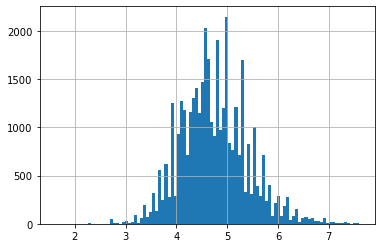

```python
df.log_price.hist(bins=100)
```

### Variables independientes

Las variables independientes son aquellas características que están relacionadas con la variable objetivo, y que nos permiten predecirla. Para escogerlas debemos emplear tanto el sentido común como los conceptos teóricos que nos permitan conocer que determina el precio de un alojamiento.

Basados en nuestra intuición y conceptos previos, seleccionamos las siguientes variables que ayudarán a decidir el precio:

- property_type: Indica las propiedades del departamente (si es casa o departamento). (categórica)
- amenities: Accesorios o comodidades con los que cuenta el departamento. (categórica/lista)
- accommodates: Número de personas por habitación. (enteros)
- bathrooms: Número de baños. (enteros)
- bed_type: Tipo de cama. (categórica)
- cancellation_policy: Tipo de cancelación. (categórica)
- number_of_reviews: Número de reseñas. (enteros)
- review_scores_rating: Rating del departamento/casa en renta. (flotante)
- bedrooms: Número de habitaciones. (enteros)
- beds: Número de camas. (enteros)

Nota: Después de haber realizado la estimación, la variable de property_type no tiene las mismas dimensiones en la base de datos de entrenamiento y la de testeo, por tal motivo se decidió cambiarla por:

- room_type: Tipo de cuarto en renta. (categórica)

### Variables categóricas

Los modelos no admiten texto. Por lo que es necesario realizar alguna transformación previa para ingresarlas como datos numéricos. Las variables categóricas compuestas por texto, pueden ser codificadas asignando un número a cada opción. También pueden ser transformadas en variables dummies, que asignan un valor de 1, cuando una de las opciones están presentes o 0 cuando no lo están. Esta transformación implica crear tantas variables como opciones existan. Ahora empezamos a analizar las variables dependientes cuyo contenido es categórico.

```python
df['room_type'].value_counts()
```

```
Entire home/apt    21495
Private room       16045
Shared room          961
Name: room_type, dtype: int64
```

```python
df['cancellation_policy'].value_counts()
```

```
strict             19733
moderate           11386
flexible            7343
super_strict_30       33
super_strict_60        6
Name: cancellation_policy, dtype: int64
```

```python
df['bed_type'].value_counts()
```

```
Real Bed         37404
Futon              434
Pull-out Sofa      342
Airbed             213
Couch              108
Name: bed_type, dtype: int64
```

Creamos un objeto que contenga las dummies de las variables categóricas.

```python
variables_dummy = pd.get_dummies(df[['room_type','bed_type','cancellation_policy']])
```

```python
variables_dummy.shape
```

```
(38501, 13)
```

Con esta transformación ya podemos construir nuestras series de variables. La variable dependiente suele denotarce con **y** y las variables dependientes con **X**. Para ello, nombramos a la variable que intentamos predecir con la nomenclatura **Y**.

```python
y = df['log_price']
```

Para crear nuestro set de variables dependientes empleamos la función *concat*, que nos permite unir dos tablas con iguales dimenciones, en este caso, uniremos las varibles dummies antes generadas con las numéricas. El argumento axis = 1 indica que deseamos unir las columnas.

```python
X = pd.concat([variables_dummy, df.loc[:,['accommodates','bathrooms','number_of_reviews','review_scores_rating','bedrooms','beds']]], axis=1)
```

```python
X.shape
```

```
(38501, 19)
```

La matriz de correlación nos permite estimar si existe relación aparente entre dos variables. Los valores cercanos a uno indican una alta correlación, mientras que los cercanos a cero indican que aparentemente las variables no están relacionadas. El signo indica si la relación entre las variables es directa cuando es positivo, o inversa, cuando es negativo. En ocaciones una gráfica de temperatura de color nos permite identificar de forma más fácil si algunas de las variables estan correlacionadas. Para ello utilizaremos el siguiente mapa de calor que nos ayuadrá a identificar visualmente más rápido si existe una correlación aparente.

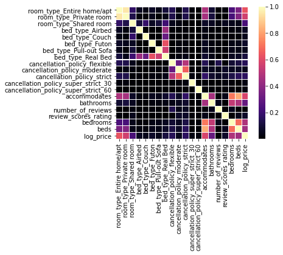

```python
sns.heatmap(np.abs(pd.concat([X,y],axis=1).corr()), linewidth=0.1, square=True, cmap='magma')
```

```python
X = X.loc[:, X.columns != 'room_type_Private room']
```

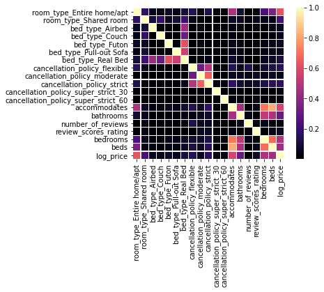

```python
sns.heatmap(np.abs(pd.concat([X,y],axis=1).corr()), linewidth=0.1, square=True, cmap='magma')
```

### Train y Test

Ya que hemos seleccionado las variables, el siguiente paso es dividirlas en las bases de entrenamiento y de prueba. El modelo se ajusta en la base de entrenamiento traning set, y se evalúa en la base de prueba test set. Esto con el fin de no predisponer el modelo, y evaluar sobre datos que aún no han sido vistos por el modelo. Regularmente se emplea el 80% de los datos para el training set y el 20% restante para el test set.

Debido al contenido de la variable *amenities*, se decidió al final sacarla del modelo, sin embargo se sugiere trabajarla como variable dummie en cada contenido de la lista ejemplo: Tele ==1/0 | Internet==1/0

Para realizar esta partición de forma aleatoria, emplearemos la función train_test_split de la librería sklearn.

```python
X_train, X_test, y_train, y_test = train_test_split(X, y)
```

```python
X_train.shape
```

```
(28875, 18)
```

```python
y_train.shape
```

```
(28875,)
```

```python
X_test.shape
```

```
(9626, 18)
```

### Creación del modelo

Ahora que ya hemos seleccionado y preparado nuestras variables objetivo e independientes, el siguiente punto es crear un objeto con el modelo que vamos a emplear. Empezaremos con un modelo de regresión lineal.

```python
lm = LinearRegression()
```

Ahora utilizaremos un fit set al trining para ajustar el modelo.

```python
lm.fit(X_train, y_train)
```

```
LinearRegression()
```

Los coeficientes del modelo se alojan en la *property coef_.*

```python
lm.coef_
```

```
array([ 6.21966788e-01, -4.89790538e-01, -6.52755704e-02,  2.63294291e-02,
       -5.36177905e-02,  7.09569872e-02,  2.16069446e-02, -2.76860658e-01,
       -2.50222841e-01, -2.01548683e-01,  1.08118921e-01,  6.20513261e-01,
        7.10114347e-02,  1.28099271e-01, -1.33883770e-04,  6.97915198e-03,
        1.58497929e-01, -5.20078003e-02])
```

Ya que tenemos la predicción del modelo emplearemos el test set para saber que tan bien ajustó el modelo. Los modelos de regresión lineal se evaluán empleando la métrica de **R^2** . Entre más cercano a uno se encuentre este parámetro, mejor capacidad de predicción tendrá el modelo.

```python
lm.score(X_test, y_test)
```

```
0.55692232826133
```

```python
lm.score(X_train, y_train)
```

```
0.5622294206094207
```

```python
rm = Ridge(alpha=1)
```

```python
rm.fit(X_train, y_train)
```

```
Ridge(alpha=1)
```

```python
rm.score(X_test, y_test)
```

```
0.55692156683635
```

```python
rm.score(X_train, y_train)
```

```
0.562225310528345
```

Probamos una regreción lineal con penalización y sin embargo el score no mejoró significativamente. Por lo que nos quedamos con los resultados de la regresión lineal. Finalmente probaremos un modelo del tipo árbol de desición, el cuál además es capaz de indicarnos la importancia de cada feature para predecir el precio.

```python
tree = DecisionTreeRegressor(max_depth=4, random_state=0)
```

```python
tree.fit(X_train, y_train)
```

```
DecisionTreeRegressor(max_depth=4, random_state=0)
```

```python
tree.score(X_test, y_test)
```

```
0.5613834470441267
```

## Resultados

```python
X.columns
```

```
Index(['room_type_Entire home/apt', 'room_type_Shared room', 'bed_type_Airbed',
       'bed_type_Couch', 'bed_type_Futon', 'bed_type_Pull-out Sofa',
       'bed_type_Real Bed', 'cancellation_policy_flexible',
       'cancellation_policy_moderate', 'cancellation_policy_strict',
       'cancellation_policy_super_strict_30',
       'cancellation_policy_super_strict_60', 'accommodates', 'bathrooms',
       'number_of_reviews', 'review_scores_rating', 'bedrooms', 'beds'],
      dtype='object')
```

Tras el análisis ahora tenemos un modelo que es capaz de predecir el precio de los alojamientos con relación a sus características. El análisis de correlación entre variables, ya nos había mostrado que la variable de precio estaba correlacionada con la variable **cuartos disponibles y cantidad de baños**, y el modelo de árboles de desición, nos permite corrovorarlo. Una vez que ha sido ajustado el modelo, la property featureimportances nos devuelve un vector con la importancia asignada a cada feature:

```python
tree.feature_importances_
```

```
array([7.11370496e-01, 2.49346203e-02, 0.00000000e+00, 0.00000000e+00,
       0.00000000e+00, 0.00000000e+00, 0.00000000e+00, 0.00000000e+00,
       0.00000000e+00, 0.00000000e+00, 0.00000000e+00, 0.00000000e+00,
       2.05189472e-02, 1.78768181e-01, 0.00000000e+00, 4.90369087e-04,
       6.05289610e-02, 3.38842495e-03])
```

```
(-1.0, 18.0)
```

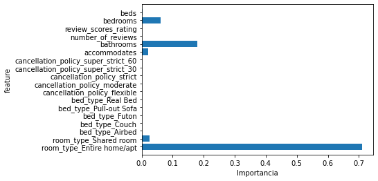

```python
n_features = X.shape[1]
plt.barh(np.arange(n_features), tree.feature_importances_, align='center')
plt.yticks(np.arange(n_features), X.columns)
plt.xlabel("Importancia")
plt.ylabel("feature")
plt.ylim(-1, n_features)
```

La gráfica muestra como la variable más importante en la toma de decisiones para el precio es si el tipo de cuarto es una casa o departamento. Así mismo, la cantidad de baños disponibles en el alojamiento es áltamente relevante con un 20%. Finalmente el número de habitaciones y de personas por casa o departamento también es importante para su ocupación total suelen cotizarce en los precios más altos.

### Predicción

Finalmente, a raíz del modelo, sólo nos queda utilizar la base proporcionada por KAVAK llamada *test.csv*- La cual contiene las observaciones a las cuales se les debe poner precio.

```python
df_test = pd.read_csv('C:/Users/lapnt/OneDrive/Documentos/Contratacion KAVAK/Work Sample/test.csv')
```

```python
df_test.head()
```

|  | id | property_type | room_type | amenities | accommodates | bathrooms | bed_type | cancellation_policy | cleaning_fee | city | ... | latitude | longitude | name | neighbourhood | number_of_reviews | review_scores_rating | thumbnail_url | zipcode | bedrooms | beds |
| --- | --- | --- | --- | --- | --- | --- | --- | --- | --- | --- | --- | --- | --- | --- | --- | --- | --- | --- | --- | --- | --- |
| 0 | 3895911 | Apartment | Private room | {TV,"Cable TV",Kitchen,"Free parking on premis... | 2 | 1.0 | Real Bed | flexible | True | LA | ... | 34.028372 | -118.494449 | Santa Monica Private Bedroom/Bathroom Suite | Santa Monica | 6 | 97.0 | https://a0.muscache.com/im/pictures/92355eae-b... | 90403 | 1.0 | 1.0 |
| 1 | 9710289 | Apartment | Entire home/apt | {TV,"Cable TV","Wireless Internet","Air condit... | 3 | 1.0 | Real Bed | moderate | True | NYC | ... | 40.720380 | -73.942329 | Bright, charming luxury 1 BR with amazing rooftop | Williamsburg | 2 | 80.0 | https://a0.muscache.com/im/pictures/da03e413-d... | 11222 | 1.0 | 1.0 |
| 2 | 9051635 | Apartment | Private room | {"Wireless Internet",Kitchen,Heating,"Family/k... | 1 | 1.0 | Real Bed | moderate | True | SF | ... | 37.785434 | -122.470284 | Private room in charming apartment | Richmond District | 2 | 100.0 | https://a0.muscache.com/im/pictures/0ba7d8aa-9... | 94118 | 1.0 | 1.0 |
| 3 | 708374 | Apartment | Entire home/apt | {TV,"Cable TV",Internet,"Wireless Internet","W... | 1 | 1.0 | Real Bed | strict | True | LA | ... | 33.976026 | -118.463471 | Marina del Rey Beach Jr 1 Bdrm 5 | Marina Del Rey | 7 | 94.0 | https://a0.muscache.com/im/pictures/30279741/4... | 90292 | 0.0 | 1.0 |
| 4 | 626296 | Apartment | Entire home/apt | {TV,Internet,"Wireless Internet","Air conditio... | 2 | 1.0 | Real Bed | flexible | True | NYC | ... | 40.735573 | -74.005996 | Bright Studio Loft Prime Location | West Village | 0 | NaN | https://a0.muscache.com/im/pictures/9384e262-8... | 10014 | 1.0 | 1.0 |

5 rows × 28 columns

Ahora debemos dar el mismo tratamiento para pasar las variables categóricas a Doomies y quedarnos sólamente con las variables de interés

```python
df_test = df_test.dropna()
```

```python
df_test.shape
```

```
(13138, 28)
```

```python
df_test['room_type'].value_counts()
```

```
Entire home/apt    7352
Private room       5413
Shared room         373
Name: room_type, dtype: int64
```

```python
variables_dummy_Test = pd.get_dummies(df_test[['room_type','bed_type','cancellation_policy']])
```

```python
variables_dummy_Test.shape
```

```
(13138, 13)
```

```python
Mis_departamentos = pd.concat([variables_dummy_Test, df_test.loc[:,['accommodates','bathrooms','number_of_reviews','review_scores_rating','bedrooms','beds']]], axis=1)
```

```python
Mis_departamentos.shape
```

[output not shown]

```python
Mis_departamentos = Mis_departamentos.loc[:, Mis_departamentos.columns != 'room_type_Private room']
```

```python
Mis_departamentos['log_price'] = lm.predict(Mis_departamentos)
```

```python
Mis_departamentos.head()
```

|  | room_type_Entire home/apt | room_type_Shared room | bed_type_Airbed | bed_type_Couch | bed_type_Futon | bed_type_Pull-out Sofa | bed_type_Real Bed | cancellation_policy_flexible | cancellation_policy_moderate | cancellation_policy_strict | cancellation_policy_super_strict_30 | cancellation_policy_super_strict_60 | accommodates | bathrooms | number_of_reviews | review_scores_rating | bedrooms | beds | log_price |
| --- | --- | --- | --- | --- | --- | --- | --- | --- | --- | --- | --- | --- | --- | --- | --- | --- | --- | --- | --- |
| 0 | 0 | 0 | 0 | 0 | 0 | 0 | 1 | 1 | 0 | 0 | 0 | 0 | 2 | 1.0 | 6 | 97.0 | 1.0 | 1.0 | 4.269616 |
| 1 | 1 | 0 | 0 | 0 | 0 | 0 | 1 | 0 | 1 | 0 | 0 | 0 | 3 | 1.0 | 2 | 80.0 | 1.0 | 1.0 | 4.871122 |
| 2 | 0 | 0 | 0 | 0 | 0 | 0 | 1 | 0 | 1 | 0 | 0 | 0 | 1 | 1.0 | 2 | 100.0 | 1.0 | 1.0 | 4.246715 |
| 3 | 1 | 0 | 0 | 0 | 0 | 0 | 1 | 0 | 0 | 1 | 0 | 0 | 1 | 1.0 | 7 | 94.0 | 0.0 | 1.0 | 4.716314 |
| 7 | 1 | 0 | 0 | 0 | 0 | 0 | 1 | 0 | 0 | 1 | 0 | 0 | 3 | 1.0 | 3 | 93.0 | 0.0 | 2.0 | 4.799885 |

En la tabla *Mis_departamentos* encontramos la variable creada a partir de nuestro modelo con la función lm.predict la cual nos arroja el logaritmo del precio de acuerdo a los datos recaudados por la base de test.csv. Ahora convertiremos los logaritmos en exponentes para poder ver cuál sería el precio sugerido.

```python
Mis_departamentos['precio_calculado'] = np.exp(Mis_departamentos['log_price'])
```

```python
Mis_departamentos.head()
```

|  | room_type_Entire home/apt | room_type_Shared room | bed_type_Airbed | bed_type_Couch | bed_type_Futon | bed_type_Pull-out Sofa | bed_type_Real Bed | cancellation_policy_flexible | cancellation_policy_moderate | cancellation_policy_strict | cancellation_policy_super_strict_30 | cancellation_policy_super_strict_60 | accommodates | bathrooms | number_of_reviews | review_scores_rating | bedrooms | beds | log_price | precio_calculado |
| --- | --- | --- | --- | --- | --- | --- | --- | --- | --- | --- | --- | --- | --- | --- | --- | --- | --- | --- | --- | --- |
| 0 | 0 | 0 | 0 | 0 | 0 | 0 | 1 | 1 | 0 | 0 | 0 | 0 | 2 | 1.0 | 6 | 97.0 | 1.0 | 1.0 | 4.269616 | 71.494159 |
| 1 | 1 | 0 | 0 | 0 | 0 | 0 | 1 | 0 | 1 | 0 | 0 | 0 | 3 | 1.0 | 2 | 80.0 | 1.0 | 1.0 | 4.871122 | 130.467186 |
| 2 | 0 | 0 | 0 | 0 | 0 | 0 | 1 | 0 | 1 | 0 | 0 | 0 | 1 | 1.0 | 2 | 100.0 | 1.0 | 1.0 | 4.246715 | 69.875503 |
| 3 | 1 | 0 | 0 | 0 | 0 | 0 | 1 | 0 | 0 | 1 | 0 | 0 | 1 | 1.0 | 7 | 94.0 | 0.0 | 1.0 | 4.716314 | 111.755541 |
| 7 | 1 | 0 | 0 | 0 | 0 | 0 | 1 | 0 | 0 | 1 | 0 | 0 | 3 | 1.0 | 3 | 93.0 | 0.0 | 2.0 | 4.799885 | 121.496477 |

Una vez corroborada la información, guardamos la base de datos con los precios sugeridos

```python
Mis_departamentos.to_csv('C:/Users/lapnt/OneDrive/Documentos/Contratacion KAVAK/Work Sample/base_preciosID.csv')
```